# Final Project

2023-11-30

## Angelic

**Research Question**

### Do states with the highest SNAP participation also reflect the highest healthcare coverage?

```r
#I took the average of Total(population) for each state across the years to calculate the Average Population for each state. Then I added it to a new dataframe named SNAP_healthcare.
SNAP_healthcare <- merged_data %>%
  group_by(State) %>%
  summarise(`Average Population` = mean(`Total`))
```

```r
#I took the average of SNAP Persons Participation for each state across the years. Then divided that by the Average Population to get the percentage of average SNAP participation for each state.
SNAP_participation <- merged_data %>%
  group_by(State) %>%
  summarise(Average_SNAP_Persons = mean(`SNAP Persons Participation`))

SNAP_healthcare <- left_join(SNAP_healthcare, SNAP_participation, by = "State")

SNAP_healthcare$snap_participation_percent <- (SNAP_healthcare$Average_SNAP_Persons / SNAP_healthcare$`Average Population`) * 100

head(SNAP_healthcare)
```

```
## # A tibble: 6 × 4
##   State      `Average Population` Average_SNAP_Persons snap_participation_perc…¹
##   <chr>                     <dbl>                <dbl>                     <dbl>
## 1 Alabama                4951933.              755904.                     15.3
## 2 Alaska                  733055.               87840.                     12.0
## 3 Arizona                7273885               841978.                     11.6
## 4 Arkansas               3023128.              352458.                     11.7
## 5 California            39393482              4082569.                     10.4
## 6 Colorado               5770628.              471405.                      8.17
## # ℹ abbreviated name: ¹snap_participation_percent
```

```r
#Calculating the percentage of healthcare coverage for each state, and then computing the average healthcare coverage across all the years.
healthcare_coverage <- merged_data %>%
  mutate(Healthcare_Coverage_Percentage = (`With public health coverage` / Total * 100))

average_healthcare_coverage <- healthcare_coverage %>%
  group_by(State) %>%
  summarise(Average_Healthcare_Coverage_Percentage = mean(Healthcare_Coverage_Percentage, na.rm = TRUE))
```

```r
#Merging the dataset with average SNAP participation percentage and the dataset with average healthcare coverage percentage.
merged_SNAP_healthcare <- merge(average_healthcare_coverage, SNAP_healthcare, by = "State")

head(merged_SNAP_healthcare) ## summarization data frame
```

```
##        State Average_Healthcare_Coverage_Percentage Average Population
## 1    Alabama                               37.40889          4951933.2
## 2     Alaska                               35.07949           733054.8
## 3    Arizona                               38.63866          7273885.0
## 4   Arkansas                               44.20532          3023127.5
## 5 California                               38.60689         39393482.0
## 6   Colorado                               32.16416          5770627.8
##   Average_SNAP_Persons snap_participation_percent
## 1            755903.50                  15.264816
## 2             87840.33                  11.982778
## 3            841977.67                  11.575350
## 4            352457.83                  11.658715
## 5           4082568.67                  10.363564
## 6            471405.33                   8.169048
```

```r
percentage <- merged_SNAP_healthcare %>%
  select(State, Average_Healthcare_Coverage_Percentage, snap_participation_percent) %>%
  rename(`Healthcare Coverage` = Average_Healthcare_Coverage_Percentage,
         `SNAP Participation` = snap_participation_percent)
```

```r
#I reshaped the percentage data into long-form.
percentage_long <- percentage %>%
  pivot_longer(cols = -State, names_to = "type", values_to = "percentage")

head(percentage_long)
```

```
## # A tibble: 6 × 3
##   State   type                percentage
##   <chr>   <chr>                    <dbl>
## 1 Alabama Healthcare Coverage       37.4
## 2 Alabama SNAP Participation        15.3
## 3 Alaska  Healthcare Coverage       35.1
## 4 Alaska  SNAP Participation        12.0
## 5 Arizona Healthcare Coverage       38.6
## 6 Arizona SNAP Participation        11.6
```

BOX PLOT

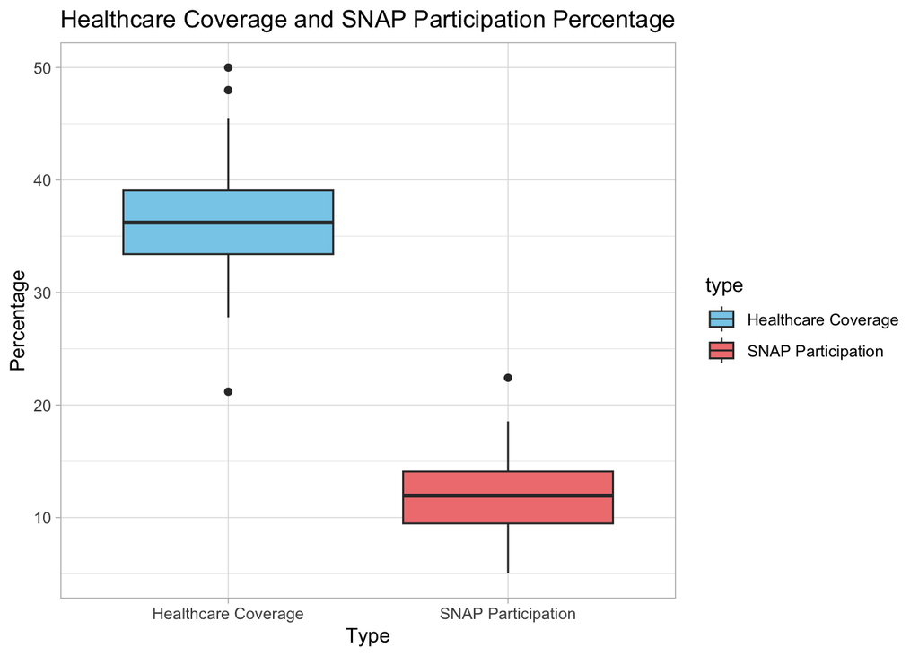

```r
#Plotting a boxplot using long form
plotHealthSnap <- ggplot(percentage_long, aes(x = type, y = percentage, fill = type)) +
  geom_boxplot() +
  scale_fill_manual(values = c("Healthcare Coverage" = "skyblue", "SNAP Participation" = "lightcoral")) +
  labs(title = "Healthcare Coverage and SNAP Participation Percentage",
       x = "Type",
       y = "Percentage") +
  theme_light()
print(plotHealthSnap)
```

```r
#Ranking the states by SNAP participation percentage.
merged_SNAP_healthcare <- merged_SNAP_healthcare %>%
  mutate(Rank_SNAP_Participation = rank(-snap_participation_percent))

head(merged_SNAP_healthcare) %>%
  select(State, Rank_SNAP_Participation)
```

```
##        State Rank_SNAP_Participation
## 1    Alabama                       7
## 2     Alaska                      25
## 3    Arizona                      30
## 4   Arkansas                      28
## 5 California                      36
## 6   Colorado                      44
```

```r
top_10_states <- merged_SNAP_healthcare %>%
  filter(Rank_SNAP_Participation <= 10) %>%
  arrange(snap_participation_percent)

worst_10_states <- merged_SNAP_healthcare %>%
  filter(Rank_SNAP_Participation > n_distinct(State) - 10) %>%
  arrange(desc(snap_participation_percent))
```

BAR PLOTS

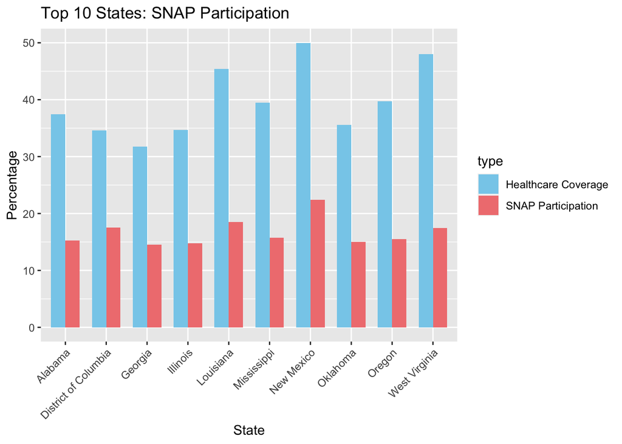

```r
#Graphing the top 10 and worst 10 states based on SNAP participation.
top_states <- percentage_long %>%
  filter(State %in% top_10_states$State)

ggplot(top_states, aes(x = State, y = percentage, fill = type)) +
  geom_bar(stat = "identity", position = "dodge", width = 0.7) +
  labs(title = "Top 10 States: SNAP Participation",
       x = "State", y = "Percentage") +
  theme(axis.text.x = element_text(angle = 45, hjust = 1)) +
  scale_fill_manual(values = c("Healthcare Coverage" = "skyblue", "SNAP Participation" = "lightcoral"))
```

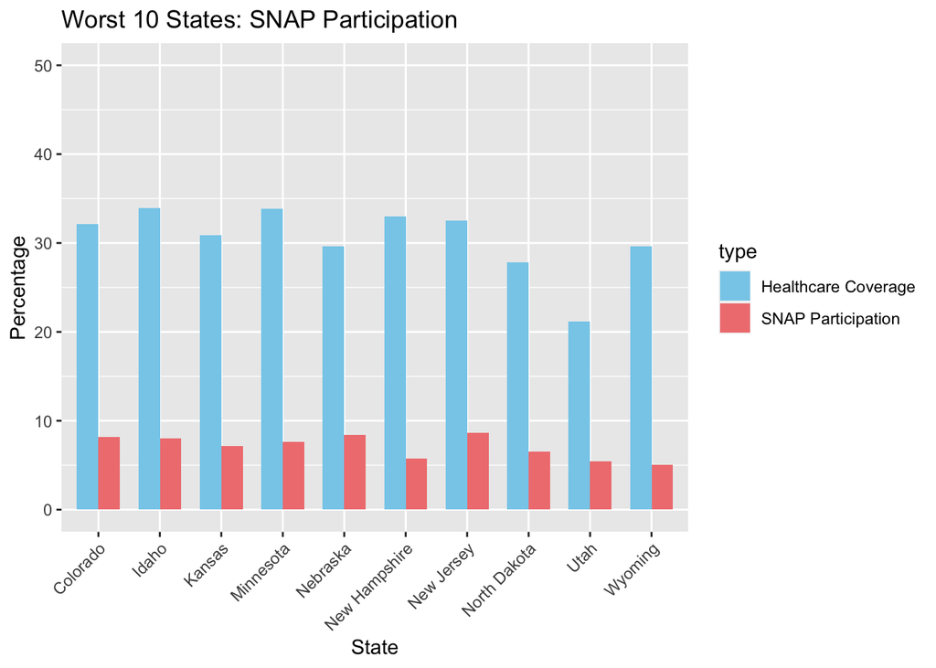

```r
worst_states <- percentage_long %>%
  filter(State %in% worst_10_states$State)

ggplot(worst_states, aes(x = State, y = percentage, fill = type)) +
  geom_bar(stat = "identity", position = "dodge", width = 0.7) +
  labs(title = "Worst 10 States: SNAP Participation",
       x = "State", y = "Percentage") +
  theme(axis.text.x = element_text(angle = 45, hjust = 1)) +
  scale_fill_manual(values = c("Healthcare Coverage" = "skyblue", "SNAP Participation" = "lightcoral")) +
  scale_y_continuous(breaks = seq(0, 50, by = 10), limits = c(0, 50))
```

```r
#Ranking the states based on healthcare coverage percentage.
merged_SNAP_healthcare <- merged_SNAP_healthcare %>%
  mutate(Rank_Healthcare_Coverage = rank(-`Average_Healthcare_Coverage_Percentage`))

top_10_healthcare <- merged_SNAP_healthcare %>%
  filter(Rank_Healthcare_Coverage <= 10) %>%
  arrange(`Average_Healthcare_Coverage_Percentage`)

worst_10_healthcare <- merged_SNAP_healthcare %>%
  filter(Rank_Healthcare_Coverage > n_distinct(State) - 10) %>%
  arrange(desc(`Average_Healthcare_Coverage_Percentage`))
```

BAR PLOTS

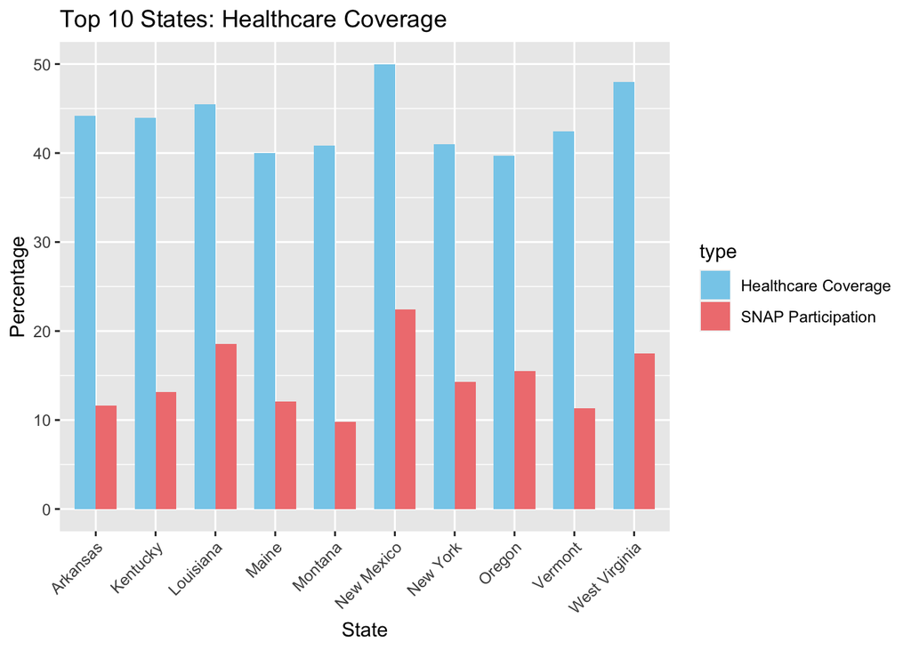

```r
#Graphing the top 10 and worst 10 states based on healthcare coverage.
top_healthcare_states <- percentage_long %>%
  filter(State %in% top_10_healthcare$State)

ggplot(top_healthcare_states, aes(x = State, y = percentage, fill = type)) +
  geom_bar(stat = "identity", position = "dodge", width = 0.7) +
  labs(title = "Top 10 States: Healthcare Coverage",
       x = "State", y = "Percentage") +
  theme(axis.text.x = element_text(angle = 45, hjust = 1)) +
  scale_fill_manual(values = c("Healthcare Coverage" = "skyblue", "SNAP Participation" = "lightcoral"))
```

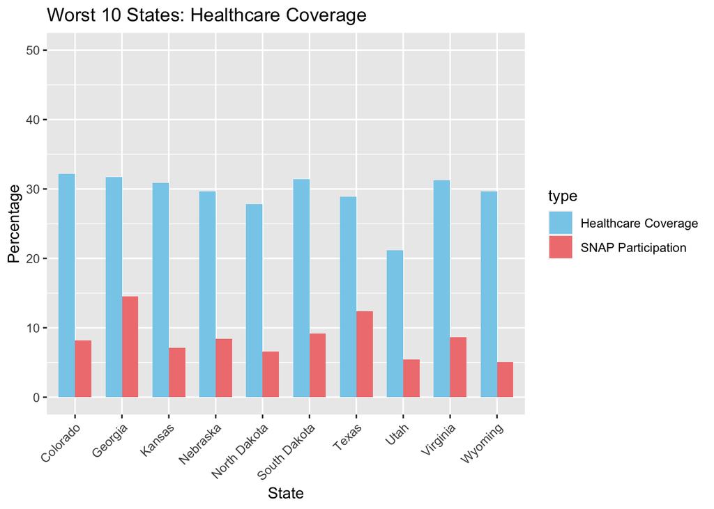

```r
worst_healthcare_states <- percentage_long %>%
  filter(State %in% worst_10_healthcare$State)

ggplot(worst_healthcare_states, aes(x = State, y = percentage, fill = type)) +
  geom_bar(stat = "identity", position = "dodge", width = 0.7) +
  labs(title = "Worst 10 States: Healthcare Coverage",
       x = "State", y = "Percentage") +
  theme(axis.text.x = element_text(angle = 45, hjust = 1)) +
  scale_fill_manual(values = c("Healthcare Coverage" = "skyblue", "SNAP Participation" = "lightcoral")) +
  scale_y_continuous(breaks = seq(0, 50, by = 10), limits = c(0, 50))
```

## Ella

**Main Question**  
Does being a primarily red or blue state affect SNAP Cost and healthcare coverage?

It’s widely believed that blue states allocate more funds to public policies like healthcare and SNAP. This analysis aims to verify whether this belief holds for healthcare coverage and SNAP expenses, with the intention of providing policymakers and other stakeholders with data-driven recommendations based on our findings.

In the context of the most recent presidential election in the United States, states are often classified as “Red” or “Blue” based on the predominant voting preference for the Republican or Democratic party, respectively.

<Red States (Republican - Donald Trump)>

Alabama,Alaska,Arkansas,Florida,Idaho,Indiana,Iowa,Kansas,Kentucky,Louisiana,Mississippi,Missouri,Montana,Nebraska,North Carolina,North Dakota,Ohio,Oklahoma,South Carolina,South Dakota,Tennessee,Texas,Utah,West Virginia,Wyoming

<Blue States (Democratic - Joe Biden)>

Arizona,California,Colorado,Connecticut,Delaware,District of Columbia,Georgia,Hawaii,Illinois,Maine,Maryland ,Massachusetts,Michigan,Minnesota,Nevada,New Hampshire,New Jersey,New Mexico,New York,Oregon,Pennsylvania,Rhode Island,Vermont,Virginia,Washington,Wisconsin

Additionally, my analysis is centered on state-level comparisons. To facilitate this, I computed the average values for key variables: health insurance coverage, and SNAP Cost Per Person. Considering the varying population sizes across states, I also calculated the ratio of healthcare insurance coverage to provide a more balanced comparison.

```
## # A tibble: 5 × 5
##   State      state_politic Mean_Healthcare_Cover_Ratio Mean_SNAP_Cost_Per_Person
##   <chr>      <chr>                               <dbl>                     <dbl>
## 1 Alabama    Red                                 0.374                      156.
## 2 Alaska     Red                                 0.351                      217.
## 3 Arizona    Blue                                0.386                      148.
## 4 Arkansas   Red                                 0.442                      128.
## 5 California Blue                                0.386                      170.
## # ℹ 1 more variable: Mean_SNAP_Cost_Per_Household <dbl>
```

Firstly, an analysis is conducted to compare the average healthcare coverage ratio with the average SNAP cost per person, grouped by whether states are predominantly Red or Blue.

Upon examining the initial plot, it becomes evident that certain outlier values obscure the underlying trends within the data. To obtain a clearer view of the patterns, the dataset will be refined by excluding entries where the average SNAP cost per person exceeds 200.

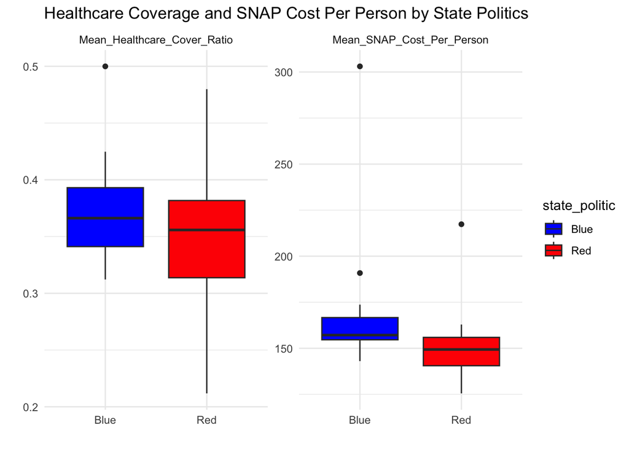

Once the outliers, specifically Alaska and Hawaii, were excluded, the data pattern became more discernible.

**Healthcare Coverage Ratio:** Blue states appear to have a higher median healthcare coverage ratio than Red states. The data for Blue states is more tightly clustered, indicating less variation in healthcare coverage ratios within these states. Red states show more variability, indicating some Red states with significantly lower healthcare coverage ratios.

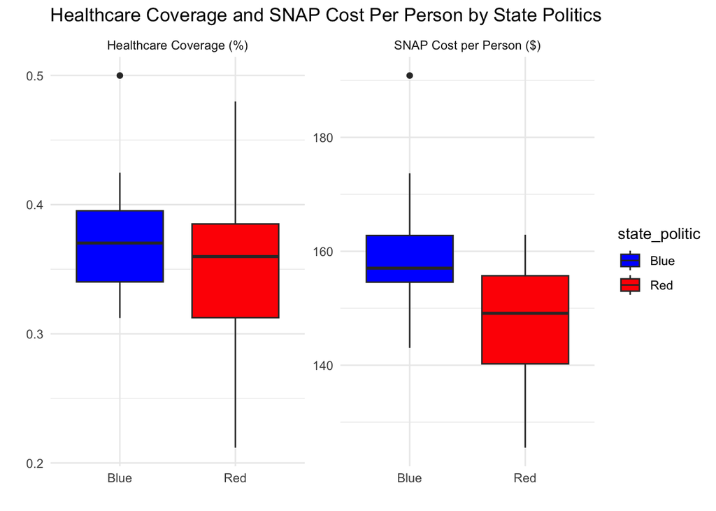

## Julia

**Research Question**  
Which racial group participates in the SNAP program the most amongst different states?

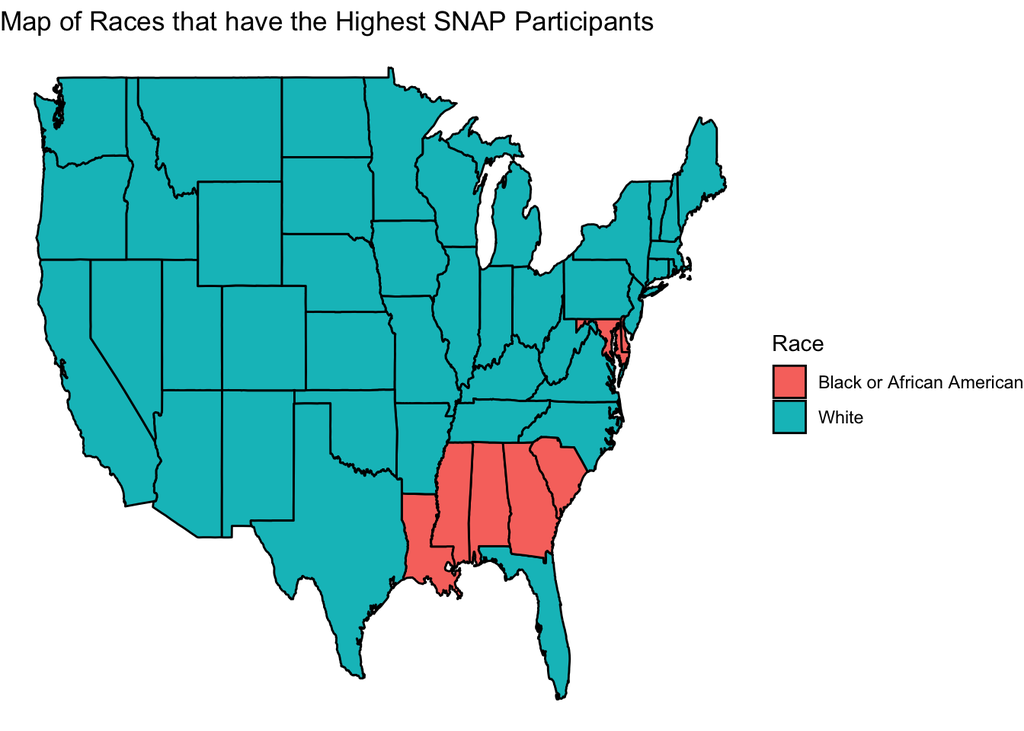

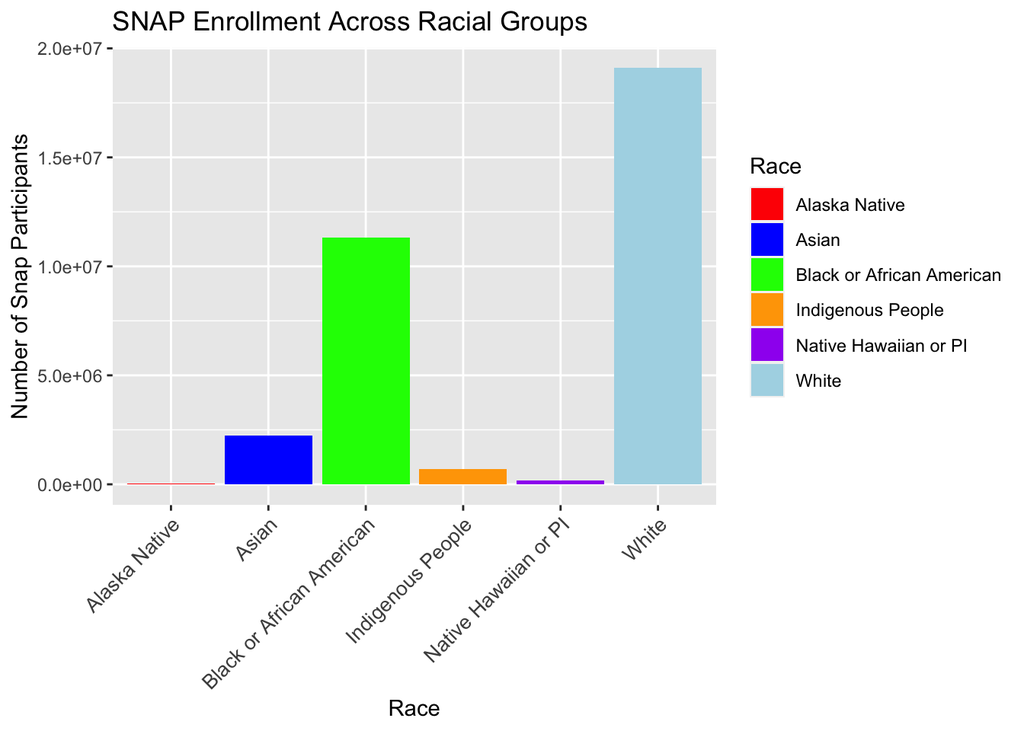

```r
#Bar Plotting
#Plotting a Bar plot to compare the race groups nationally
raceBar <- ggplot(sumSNAPbyRace) +
  geom_col(aes(x = Race, y = SumSNAPcount, fill = Race)) +
  scale_fill_manual(values = c("red", "blue", "green", "orange", "purple","lightblue")) +
  labs(title = "SNAP Enrollment Across Racial Groups",
       x = "Race",
       y = "Number of Snap Participants") +
  theme(axis.text.x = element_text(angle = 45, hjust = 1, size = 10))
print(raceBar)
```